# Day 1: Getting data into shape

## P6: Joining datasets

- merges/combining joins

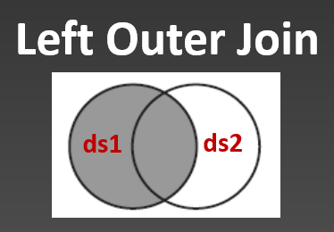

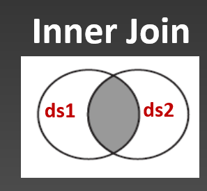

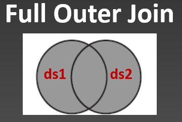

```r
# whole suite joins....
  left_join()  # stick this one
  right_join() # just switch around to left_join
  full_join()  # safer to create the fuller design (e.g. expand.grid) and then left_join() into it
  inner_join() # safer to do left_join() and then filter()
  outer_join() # just stick to left_join and filter()

# note- there is bind_cols() but best to avoid and use a left_join() instead
```

### Commentary on merges/join (left_join)

You will join datasets are the time. In joins, (usually) you have two datasets and have something in common (e.g. site_id). For instance, you may have response variable in one dataset and covariates in another. You want to combine together.

Be warned, joins can be major pitfalls!!!! If you are not intimate ❤️ with your datasets, it can lead to big issues. We showed this in our code in which we “forgot” to include transect_id:

```r
# as an example, left_join will warn you if it is not a one-to-one join
  ds_mistake <- left_join( ds_survey, select(ds_site, wetland, fence, grazing) )
  nrow(ds_mistake) # way bigger
```

What happened here is called a one-to-many join. I was expecting the left dataset (the first dataset) to have the same number of rows before and after the join. Instead, it has more, creating fake data in essence (and increasing sample size, decreasing SEs, leading to erroneous stats). Therefore, you really need to keep tabs on number of rows.

Luckily, `dplyr::left_join()` brought in a warning for this (I had my own function to warn me about this). My advice for you is to only use `left_join()` and make it a one-to-one join. Be careful being fancy in one-to-many and many-to-many (`full_join`) joins. Sometimes it is safer to work in separate steps rather than one big step.

### Join for our project

Now that is off my chest, let’s recall the joins we needed for our project…

```r
# now join in grazing, fence info...use a left_join and join by wetland, transect_id
  nrow(ds_survey)
  ds_survey <- left_join( ds_survey,
                          select(ds_site, wetland, transect_id, fence, grazing) )
  nrow(ds_survey) # same number as before, all good

  # as an example, left_join will warn you if it is not a one-to-one join
  ds_mistake <- left_join( ds_survey, select(ds_site, wetland, fence, grazing) )
  nrow(ds_mistake) # way bigger

#_____________________________________________________________________________
#### Section 3: import richness ####
  excel_sheets(file_excel)
  ds_richness <- read_excel(file_excel, sheet='spp_rich' )
  ds_richness  # column types look good

  # only keeping native
  ds_richness <- select(ds_richness, survey_id, native)


  # let's add richness to ds_survey
  # going to do a few checks
  filter(ds_richness, !(survey_id %in% ds_survey$survey_id) ) # all good!

  # do a histogram/density plot
  ggplot(ds_richness, aes(native)) + geom_histogram() +
    geom_density(aes(y=after_stat(count) ),alpha=0.2, fill='red') # no obvious outliers at this point

  # add richness to ds_survey
  ds_richness_out <- left_join(ds_survey,
                         ds_richness)
  ds_richness_out

  filter(ds_richness_out, is.na(native)) # 46 rows of NA...check with researcher
```

### Concatenating - Stacked joins

I did not use concatenating in this dataset. A common use for this is when you have multiple files produced that have the same data structure (e.g. acoustic data from loggers, camera trap data, acoustic moth data) and you need to stack them together for the analysis. You will use `bind_rows()` for that.

```r
  ds1 <- data.frame( plot='plot1', quadrat=1:2, species_richness=c(10,20), comments=c('none','something'))
  ds1
```

```
   plot quadrat species_richness  comments
1 plot1       1               10      none
2 plot1       2               20 something
```

```r
  ds2 <- data.frame( plot='plot2', quadrat=1:2, species_richness=c(2,4))
  ds2
```

```
   plot quadrat species_richness
1 plot2       1                2
2 plot2       2                4
```

```r
  bind_rows(ds1, ds2)
```

```
   plot quadrat species_richness  comments
1 plot1       1               10      none
2 plot1       2               20 something
3 plot2       1                2      <NA>
4 plot2       2                4      <NA>
```

there is a `bind_cols()` to add columns next to each other. I rarely use, preferring to use a join to make sure everything lines up

## P6: Saving the data files

Finally, we have sparkly-clean datasets (and hopefully no hidden dirt under the rugs). The final step in the `importData.r` is to save in the `data/rds` to be used for the next step: modelling!

### RDS approach

At the end of the import and clean stage, I save the dataset(s) as an RDS file. The advantage of this method is that you are saving the dataset(s) in native R format so when you bring back in, there is no conversion.

```r
#_____________________________________________________________________________
#### Section 5: save datasets ####

  saveRDS(ds_richness_out, 'data/rds/ards_richness.rds')
  saveRDS(ds_ht_out, 'data/rds/ards_height.rds')
```

### Excel

You may want to save an excel file to share. You will need the `writexl` package for this.

```r
# excel file
  writexl::write_xlsx( ds_richness, 'data/export/ards_richness.xlsx')
```

### CSV/Table

Or if you prefer low overhead files (smaller size).

```r
 readr::write_csv( ds_richness,file='ards_richness.csv')
 readr::write_delim( ds_richness,file='ards_richness.txt',delim = '\t') # tab
```

# Help!!!!!!!!

When learning and using R, you will get stuck and need help. There are variety of help sources we use on a daily basis.

1. Built-in to Rstudio are help files. This provides an initial starting place if you are interested in how to use a specific function. You just need to put “?” before the function and press run: `?mean()` or use the `Help` tab
2. Google search (e.g. stackoverflow, blogs) can be really helpful for finding new functions, packages, etc.
3. Biometrics - happy to provide guidance/tips/thoughts
4. ARI’s QEARI - hacky hour or Teams chat

[figure not shown]

5. AI is becoming more and more useful [I am finding the most useful]

## Using AI for coding

A few AI I use regularly:

- **Copilot (Microsoft)**: allrounder AI which we have a free subscription at ARI. It does a decent job [I use this one daily]
- **ChatGPT**: another allrounder similar to Copilot
- **Claude**: prefer this one for writing text but seems to work well too
- **Copilot-GitHub**: paid subscription but supposedly really good for programming

For those not regularly using AI, there are a few things that can help when running your searches for help:

- when asking for an example, include lots of specific to get closer to what you want. You may want to tell it to use only tidyverse functions for the example code. I often ask it to use a built-in dataset for the example so that I can check it right away.
- Experiment and Iterate: Don’t be afraid to experiment with the code generated by AI. Modify it, run it, and see what happens. If something is not working, you can ask point out the error and see if it can fix it
- Use AI for Debugging: If you encounter errors, AI tools can help you debug your code. They can suggest fixes and optimizations, making the debugging process less daunting.

Give it try yourself [copilot](https://copilot.microsoft.com/) - type…“*in R and using mtcars dataset show me how to get the mean mpg by each cyl level?*” - if it used the `aggregate()` function, type the followup: “*can you use tidyverse functions instead?*”

[figure not shown]

# Hands-on component

**Your Task:** Create your Rproject for the workshop and import data for analysis-ready datasets

**Permutation for Newbies**

If your are new to R, you may have found the material a bit overwhelming. If so, it may be best to just download the Rproject that I have created for today and work your way through that.

# Advanced topics [Advanced]

## Quality check packages

If you know that you will be updating the import of files repeatedly, it can be worthwhile to do some upfront QC/QA checks to ensure that the data coming in is clean. There are some packages to help with that.

A few things to consider with these QA/QC:

- Are your data coming a database that **already implements QA/QC** [ideal world]
- Are you working with **large datasets** (lots of columns, separate tables)
- Is this an ongoing project so you will be **updating regularly** the analyses
- Is there an **automation process** [press run and get outputs at the end]

If you working with clean data or once off datasets, it may be best to just write your data cleaning checks as we have done here. The overhead of these packages unlikely to outweigh the added benefits. Once you are automating/updating dataset, the overhead is often easily outweighed.

Here are two packages to have a look at…

### `validate` package

You can find an overview of this package on its github page

The validate package is intended to make checking your data easy, maintainable, and reproducible.

### `pointblank` package

You can find an overview of this package on its github page

This package takes an data.frame, runs through a bunch of checks on each column and provides an useful report highlighting errors and warning (might be an error).

The basic steps are below in their graphic:

[figure not shown]

**My thoughts**: This package seems like a step-up in level of QA/QC from validate. I have used a few times but have not regularly implemented due to overhead. Probably becuase my brain is full, it takes a bit of re-leaning each time and I have not taken the time to create a template that minimises that effort.

## Big Data

When data starts to get big (millions of row), tidyverse can struggle with speed. This is huge topic but will direct you to a couple useful packages that allows you to just learn dplyr but use other quicker processes

- `dtplyr` [package](https://dtplyr.tidyverse.org/)
  - under the hood it uses the `data.table` [package](https://cran.r-project.org/web/packages/data.table/vignettes/datatable-intro.html)
  - but you write code in tidy/dplyr
- `dbplyr` [package](https://dbplyr.tidyverse.org/) [if working with a database]
  - has the database do all the processes and return the result back to R
  - takes advantage of cloud computing

## Learn functions

A fundamental skill in coding is creating functions. Packages are basically just collection of functions. I write functions all the time. This helps keep code clean, are reusable (so saves time), helps prevent cut/paste errors, and improves readability/reproducibility. Definitely worth learning as some point.

```r
my_plus_function <- function(x,y){
    x + y
}

my_plus_function(1,2)
```

# Resources

Obviously, we have only scratched the surface of the topics here. Here are couple books I have used but lots out there.

[R for Data Science](https://r4ds.hadley.nz/)

[Advanced R](https://adv-r.hadley.nz/)